# Product_Tolerances_v1-0

**Product Dimensions - Salvaging $70,000+ of Defective Inventory**

Tens of thousands of units are out-of-spec in a factory's warehouse with a defect rate of 100%, representing a potential massive loss to the factory. However, the customer is willing to consider loosening the quality requirements (the product dimensional tolerances) to make an urgent shipment. The customer wants as many units as possible to ship, but is reluctant to loosen product tolerances any more than absolutely needed.

*How do we optimize a proposal to the customer that maximizes shipments of currently out-of-spec parts yet minimizes the loosening of quality standards that the customer needs to make?*

[figure not shown]

## Background info

From the tens of thousands of units produced, 192 samples were taken and measured at each of 8 dimensions. The product's technical drawing identifies the standard measurement (called the "nominal" value) and the "tolerances" allowed for each of these 8 critical dimensions.

For example, if a product's height is specified as "10cm +/- 0.5cm", this means the nominal (standard) value is 10cm, but plus or minus 0.5cm would be deemed as acceptable. A height of 10.25cm would be "in-spec" (within the specification), whereas a height of 9.4cm would be considered "out-of-spec", and thus would be rejected by Quality Control.

So the measurement data for the 192 samples will be the foundation of our analysis and proposal.

## Optimizing the Original Proposal

As we'll see in more detail later, the factory presented three proposals to the customer, each proposing a set of constant tolerance limits across all 8 dimensions.

In this case study, we'll:

> 1. Clean up and prepare the data for analysis
> 2. Examine the factory's three proposals vs. the original situation
> 3. Optimize the proposal

# #1 - Clean and Prepare the Data for Analysis

First, we'll import the packages needed for this project:

```python
import pandas as pd
import numpy as np
import matplotlib.pyplot as plt
from matplotlib.pyplot import cm
from matplotlib.colors import ListedColormap
import seaborn as sns
import scipy.stats as stats
import matplotlib.ticker as mtick
import matplotlib.patches as mpatches
import matplotlib as mpl
```

Then, we'll read in the data from a single Excel file and do some cleaning up.

```python
samples = pd.read_excel("product_tolerances.xlsx",
                      names=["Sample", "Dim1", "Dim2", "Dim3", "Dim4", "Dim5",
                             "Dim6", "Dim7", "Dim8"]
                       )
toler = pd.read_excel("product_tolerances.xlsx",
                      sheet_name="Proposals",
                      usecols=list(range(0,9)),
                      names=["Name", "Dim1", "Dim2", "Dim3", "Dim4", "Dim5",
                             "Dim6", "Dim7", "Dim8"]
                     )
toler.iloc[1:, :] = toler.iloc[1:, :].applymap(lambda x: x.replace("-", ""))
```

Now, we'll take the simple tolerance data we have (i.e. "10cm +/- 0.5cm") and expand it out to calculate the tolerances for each dimension in each proposal. Then we'll "melt" the samples dataframe into long format for easier analysis, and then merge in the proposal tolerance data. This just puts all the data we'll need for our analysis and subsequent proposals in one place to keep the data more organized and easy to access later on.

```python
def limits(x):
    nominal, tol = x.split("+")
    upper, lower = tol.split("/")
    UL = float(nominal) + float(upper)
    LL = float(nominal) - float(lower)
    return float(nominal), UL, LL, float(upper), float(lower), "+" + tol

# Create a single DF with expanded info from the original limited info
_toler_list = [[limits(toler.iloc[x,i]) for i in range(1, 9)] for x in range(1, 5)]
toler = pd.concat(
    [pd.DataFrame(
        x,
        index=["Dim" + str(x) for x in range(1,9)],
        columns=["Nominal", "UL", "LL", "Upp_Tol", "Low_Tol", "Full"]
    )
                  for x in _toler_list], axis=0
)
toler['proposal'] = (['original'] * 8 + ['proposal_1'] * 8
                  + ['proposal_2'] * 8 + ['proposal_3'] * 8)
toler["Total_tol"] = toler.Upp_Tol + toler.Low_Tol

# Melt samples into long tidy format
samples = samples.melt(id_vars="Sample", var_name="Dimension", value_name="Measurement")

# Merge Tolerance DF into Samples DF to get everything in one DF, "df"
df = pd.merge(samples, toler, how="outer", left_on="Dimension", right_index=True)
df["delta"] = df.Measurement - df.Nominal
df["in_spec"] = (df.delta < df.Upp_Tol) & (df.delta > -df.Low_Tol)
df["Dim"] = df.Dimension.apply(lambda x: x.replace("Dim", ""))
```

### Dimension #1: An Example

As we noted above, any product that exceeds the Upper Limit ("UL") or dips below the Lower Limit ("LL") on any dimension is deemed "out-of-spec" and therefore is a defective part which cannot be shipped. And the more parts that cannot be shipped, the more money the factory loses.

Let's look at Dimension #1 as an example below. We can see that most of the 192 samples fall outside the "in-spec" tolerance and are thus defective parts.

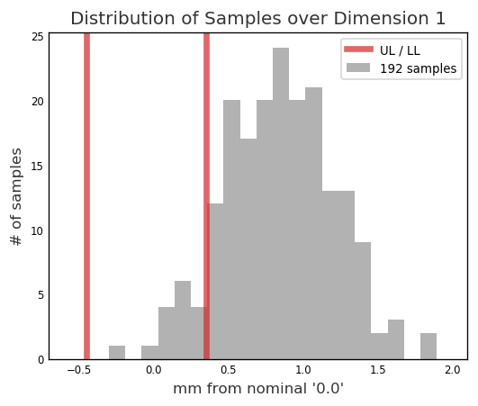

```python
mpl.rcParams['figure.dpi'] = 120

fig, ax = plt.subplots()
_dim1 = df.loc[(df.Dimension=="Dim1") & (df.proposal=="original"), "delta"]
_upp_tol = df.loc[(df.Dimension=="Dim1") & (df.proposal=="original"), "Upp_Tol"].mean()
_low_tol = df.loc[(df.Dimension=="Dim1") & (df.proposal=="original"), "Low_Tol"].mean()

ax.hist(_dim1, bins=20, color="tab:gray", alpha=0.6, label="192 samples")
ax.set_title("Distribution of Samples over Dimension 1", fontsize=12, alpha=0.8)
ax.axvline(_upp_tol, color="tab:red", linewidth=4, alpha=0.7, label="UL / LL")
ax.axvline(-_low_tol, color="tab:red", linewidth=4, alpha=0.7)
ax.set_xlim(-0.7, 2.1)
ax.tick_params(axis="both", which="both", length=0, labelsize=7)
ax.set_xlabel("mm from nominal '0.0'", fontsize=10, alpha=0.8)
ax.set_ylabel("# of samples", fontsize=10, alpha=0.8)
fig.set_size_inches(5, 4)
ax.legend(fontsize=8)
plt.show()
```

We can calculate the precise value below as 7.8% of samples being in-spec; the rest are defective.

```python
_total_samples = df.loc[(df.Dimension=="Dim1") & (df.proposal=="original"), "in_spec"]
_total_dim1_good = _total_samples.sum() / len(_total_samples)
print('{0:.2%}'.format(_total_dim1_good))
```

```
7.81%
```

And this is only considering 1 of the 8 dimensions. For a product to be considered "in-spec" and thus be able to ship to the customer, all 8 dimensions need to be within specification.

But what are the chances the 7.8% of parts that survived Dimension 1 will also pass Dimensions 2 through 8?

Taking a quick look at the 192 samples, we see that a total of 0 pieces are good parts that pass all 8 dimensions. So 100% of these parts are "out-of-spec".

```python
df.loc[df.proposal=="original", :].groupby("Sample")["in_spec"].agg("min").sum()
```

```
0
```

# #2 - Examine the Factory Proposals vs. the Original Situation

The factory presented 3 proposals to widen the tolerances:

> 1. Widen each dimension to +/- 1.0mm
> 2. Widen each dimension to +/- 1.5mm
> 3. Widen each dimension to +/- 2.0mm

Using the same histogram above which shows the distribution of Dimension 1 measurements overlaid with the Upper Limit and Lower Limit lines in red, let's also overlay these three factory proposals and visualize what these proposals' effects would be on Dimension 1:

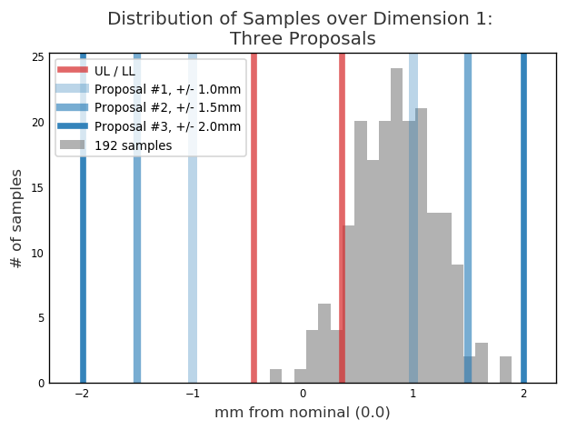

```python
p1 = 1.0
p2 = 1.5
p3 = 2.0
alphas = [0.3, 0.6, 0.9]
proposals = list(zip([p1, p2, p3], alphas))
p_color = "tab:blue"

fig, ax = plt.subplots()
ax.hist(_dim1, bins=20, color="tab:gray", alpha=0.6, label="192 samples")
ax.set_title("Distribution of Samples over Dimension 1: \nThree Proposals",
             fontsize=12, alpha=0.8)
ax.axvline(_upp_tol, color="tab:red", linewidth=4, alpha=0.7, label="UL / LL")
ax.axvline(-_low_tol, color="tab:red", linewidth=4, alpha=0.7)

for p in proposals:
    x = proposals.index(p)+1
    ax.axvline(p[0], color=p_color, linewidth=7-x, alpha=p[1],
               label="Proposal #{}, +/- {}mm".format(x, p[0]))
    ax.axvline(-p[0], color=p_color, linewidth=7-x, alpha=p[1])

ax.set_xlim(-2.3, 2.3)
ax.tick_params(axis="both", which="both", length=0, labelsize=7)
ax.set_xlabel("mm from nominal (0.0)", fontsize=10, alpha=0.8)
ax.set_ylabel("# of samples", fontsize=10, alpha=0.8)
ax.legend(fontsize=8)
fig.set_size_inches(6, 4)
```

From these three proposals, we can see that Proposal 2 would capture most of the parts, whereas Proposal 3 would capture a few more units but with diminishing returns in relation to the extra tolerances added.

From this graph, you may already see the problem yourself. These three factory proposals do not consider the individual distributions across each dimension. As a result, the proposals will naturally be loosening tolerances where it's not needed, and in other cases not loosening enough.

Before we go further, let's quantify the two factors we're trying to optimize:

> 1. **Maximizing the percentage of parts that can be shipped** (measured by percentage of parts "in-spec")
> 2. **Minimizing the widening of dimensional tolerances** (measured by the cumulative number of millimeters added to the original tolerances)

Here's what the Original Situation looks like when graphed on these metrics. On the x-axis, we didn't widen any tolerance yet and this Original Situation is the baseline that the other proposals will be judged by, so this is "0" mm added. On the y-axis, we calculated that 0% of parts are "in-spec".

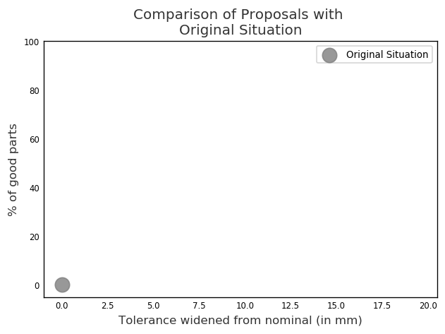

```python
fig, ax = plt.subplots()

ax.scatter(0, 0, marker="o", s=150, color="tab:gray", alpha=0.8, label="Original Situation")
ax.set_xlim(-1, 20.5)
ax.set_ylim(-5, 100)
ax.legend(labelspacing=1.5, fontsize=8)
ax.set_title("Comparison of Proposals with \nOriginal Situation", fontsize=12, alpha=0.8)
ax.set_ylabel("% of good parts", fontsize=10, alpha=0.8)
ax.set_xlabel("Tolerance widened from nominal (in mm)", fontsize=10, alpha=0.8)
ax.tick_params(axis="both", which="both", length=0, labelsize=7)
fig.set_size_inches(6, 4)
```

Now let's see how the 3 factory proposals look in comparison:

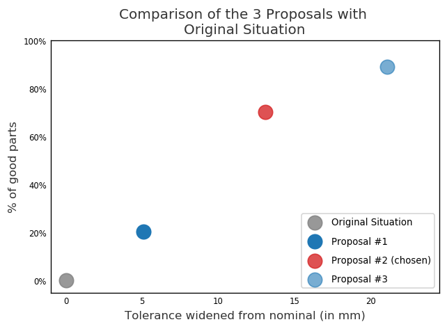

```python
# Calculate the Total Tolerance added by each Proposal, to use for X
_total_tol_added = df.groupby(["proposal"])["Total_tol"].agg("mean") * 8
_total_tol_added = _total_tol_added.apply(lambda x: x - _total_tol_added['original'])

# Calculate number of units which pass all 8 dimensions per each proposal's tolerances
_units_passed = (df.groupby(["proposal", "Sample"])["in_spec"]
                 .agg("sum")==8).groupby("proposal").agg("sum") / 192

def plot_compare_proposals(x_vals=_total_tol_added, y_vals=_units_passed,
                                proposals=None, area=False):
    fig, ax = plt.subplots()
    ax.scatter(x_vals[0], y_vals[0], s=150, color="tab:gray", alpha=0.8,
               label="Original Situation")
    ax.scatter(x_vals[1], y_vals[1], s=150, color="tab:blue", alpha=1.0,
               label="Proposal #1")
    ax.scatter(x_vals[2], y_vals[2], s=150, color="tab:red", alpha=0.8,
               label="Proposal #2 (chosen)")
    ax.scatter(x_vals[3], y_vals[3], s=150, color="tab:blue", alpha=0.6,
               label="Proposal #3")
    x_lim = (-1, 24.5)
    y_lim = (-0.05, 1)
    ax.set_xlim(*x_lim)
    ax.set_ylim(*y_lim)
    ax.yaxis.set_major_formatter(mtick.PercentFormatter(1.0))
    ax.set_title("Comparison of the 3 Proposals with \nOriginal Situation", fontsize=12,
                 alpha=0.8)
    ax.set_ylabel("% of good parts", fontsize=10, alpha=0.8)
    ax.set_xlabel("Tolerance widened from nominal (in mm)", fontsize=10, alpha=0.8)
    ax.tick_params(axis="both", which="both", length=0, labelsize=7)
    fig.set_size_inches(6, 4)

    if proposals != None:
        for x in proposals:
            if x == proposals[0]:
                ax.scatter(x[1], x[0], s=75, color="tab:green", alpha=0.4,
                       label="Statistics-based Proposals")
            else:
                ax.scatter(x[1], x[0], s=75, color="tab:green", alpha=0.4)
    if area==True:
        # Add the patch to the Axes
        rect = mpatches.Rectangle((x_lim[0], y_vals[2]), x_vals[2] - x_lim[0], 1-y_vals[2],
                                  linewidth=1, edgecolor='tab:green',
                                  facecolor='tab:green', alpha=0.1)
        ax.add_patch(rect)
        ax.text(3, 0.79, "improved\n proposal\n    zone ", color="tab:green", fontsize=9)

    ax.legend(loc="lower right", labelspacing=1, fontsize=8)
    plt.show()

plot_compare_proposals()
```

Proposal 1 achieves a mere 20% good parts, whereas Proposal 3 is upward to 90%, but at the cost of widening tolerances a combined 20+ mm. As such, the customer favors Proposal 2 as striking the best balance between maximizing shipments and minimizing dimensional tolerance changes.

# #3 - Optimizing the Proposal

Before we get started, let's identify on our "proposal comparison graph" where an improved and optimized proposal would land:

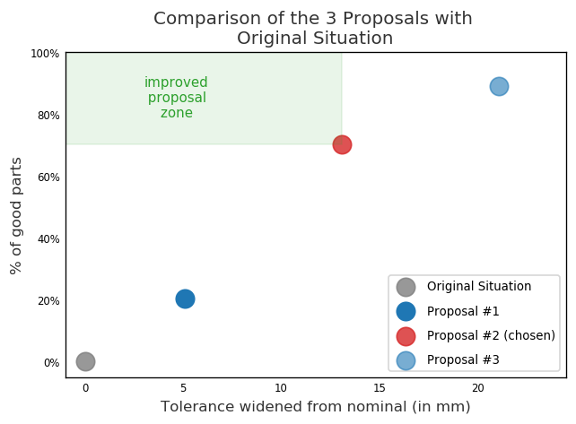

```python
plot_compare_proposals(area=True)
```

An improved proposal would either achieve:

> - the same percentage of good parts but at a lower total tolerance widened
> - the same total tolerance widened while increasing the percentage of good parts
> - both lower the total tolerance widened *and* increase the percentage of good parts

This area is represented in light shaded green in the above chart. If we can recommend a proposal that lands in that area, it's an improvement.

First, let's take a look at the distributions of the 8 dimensions. This will help give us a general picture of what's going on with each dimension.

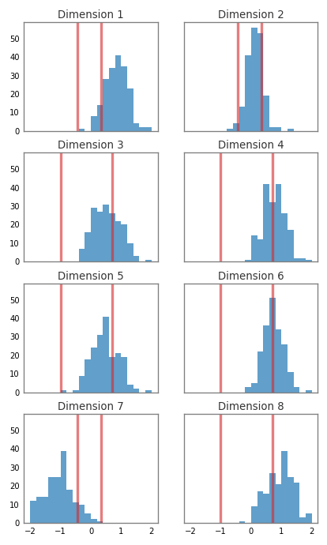

```python
def plot_eight_histograms(df=df):
    fig, axes = plt.subplots(4, 2, sharey=True, sharex=True)
    for b in range(len(axes)):
        for a in range(0,2):
            x = (b * 2) + a + 1
            x = str(x)
            ax = axes[b][a]
            ax.hist(df.loc[(df.Dim==x) & (df.proposal=="original"), "delta"],
                    bins = np.linspace(-2.0, 2.0, 21), alpha=0.7)
            ax.axvline(df.loc[(df.Dim==x) & (df.proposal=="original"), "Upp_Tol"].mean(),
                       color="tab:red", alpha=0.6, linewidth=2)
            ax.axvline(-df.loc[(df.Dim==x) & (df.proposal=="original"), "Low_Tol"].mean(),
                       color="tab:red", alpha=0.6, linewidth=2)
            ax.set_title("Dimension {}".format(x), alpha=0.8, fontsize=8, pad=3)
            ax.tick_params(axis="both", which="both", length=0, labelsize=6)
            for s in ["bottom", "top", "right", "left"]:
                ax.spines[s].set_color("tab:gray")
    fig.set_size_inches(4, 7)
    plt.show()

plot_eight_histograms()
```

Now let's view the measurements as normal distributions based on the mean and standard deviation of each dimension. These distributions and the calculations we can make from them will help guide us on where to put the Upper Limit and Lower Limit bars for an improved proposal.

The areas shaded in red represent the out-of-spec units.

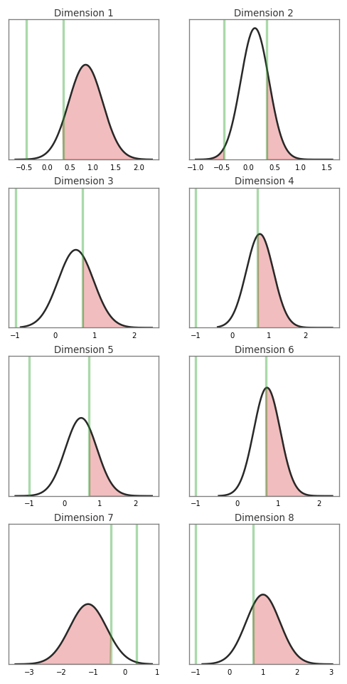

```python
def plot_dist_prob(df=df, spec="out"):
    fig, axes = plt.subplots(4, 2, sharey=True, sharex=False)
    for b in range(len(axes)):
        for a in range(0,2):
            x = (b * 2) + a + 1
            x = str(x)
            ax = axes[b][a]
            sns.distplot(df.loc[(df.Dim==x) & (df.proposal=="original"), "delta"],
                         hist=False, ax=ax, fit=stats.norm, kde=False, color="b")
            kde_x, kde_y = ax.lines[0].get_data()
            x0 = -df.loc[(df.Dim==x) & (df.proposal=="original"), "Low_Tol"].mean()
            x1 = df.loc[(df.Dim==x) & (df.proposal=="original"), "Upp_Tol"].mean()
            ax.axvline(x1, color="tab:green", alpha=0.4, linewidth=2)
            ax.axvline(x0, color="tab:green", alpha=0.4, linewidth=2)

            if spec=="in":
                ax.fill_between(kde_x, kde_y, where=((kde_x > x0) & (kde_x < x1)),
                                interpolate=True, color="tab:green", alpha=0.3)
                x_mean = df.loc[(df.Dim==x) & (df.proposal=="original"), "delta"].mean()
                x_std = df.loc[(df.Dim==x) & (df.proposal=="original"), "delta"].std()
                z0 = ((x0 - x_mean) / x_std)
                z1 = ((x1 - x_mean) / x_std)
                prob = round(calc_dual_prob(z0, z1) * 100, 1)
                ax.set_title("Dimension {}: {}% in-spec".format(x, prob), alpha=0.8,
                             fontsize=8, pad=3)
            else:
                ax.fill_between(kde_x, kde_y, where=((kde_x < x0) | (kde_x > x1)),
                            interpolate=True, color="tab:red", alpha=0.3)
                ax.set_title("Dimension {}".format(x), alpha=0.8, fontsize=8, pad=3)

            ax.tick_params(axis="both", which="both", length=0, labelsize=6)
            ax.set_xlabel("")
            ax.set_ylim(0,1.6)
            for s in ["bottom", "top", "right", "left"]:
                ax.spines[s].set_color("tab:gray")
    fig.set_size_inches(5, 10)
    plt.setp(axes, yticks=[])
    plt.show()

plot_dist_prob()
```

How can we calculate the optimal Upper and Lower Limits to maximize shipments while minimizing tolerance widening?

### Quick Detour - Calculating the probability from a distribution using upper and lower limits

Let's take a quick detour to answer a simple yet similar problem, and then apply the solution to our problem on hand.

> *There are between 240 and 280 seats on a Boeing 787 "Dreamliner" airplane, depending on the specific configuration. Given data points of "x" seats filled on 30 different flights, what is the probability that a certain 787 has 160-210 seats filled?*

The below distribution visualizes this problem (using 30 random data points representing "x" seats filled per flight). We want to calculate the area shaded in green.

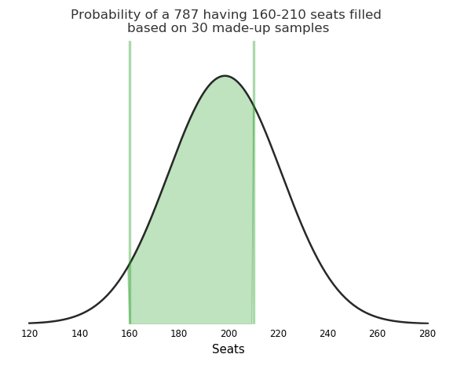

```python
np.random.seed(787)
seats = np.array(list(map(lambda x: int(x), np.random.normal(200, 22, 30))))
seats_mean = seats.mean()
seats_std = seats.std()

fig, ax = plt.subplots()
sns.distplot(seats, hist=False, fit=stats.norm, kde=False, color="b")
kde_x, kde_y = ax.lines[0].get_data()
x0 = 160
x1 = 210
ax.fill_between(kde_x, kde_y, where=((kde_x > x0) & (kde_x < x1)), interpolate=True,
                color="tab:green", alpha=0.3)
ax.axvline(x1, color="tab:green", alpha=0.4, linewidth=2)
ax.axvline(x0, color="tab:green", alpha=0.4, linewidth=2)
ax.set_title("Probability of a 787 having 160-210 seats filled \nbased on 30 made-up samples",
             alpha=0.8, fontsize=10)
ax.tick_params(axis="both", which="both", length=0, labelsize=7)
ax.set_xlabel("Seats", fontsize=9)
ax.set_ylim(0,0.02)
for s in ["bottom", "top", "right", "left"]:
    ax.spines[s].set_color("white")
plt.setp(ax, yticks=[])
fig.set_size_inches(6, 4)
plt.show()
```

The first step is to calculate the mean and standard deviation of the dataset. Then we convert our lower limit and upper limit values to z-values so that we can compute the probability.

```python
z0 = ((x0 - seats_mean) / seats_std)
z1 = ((x1 - seats_mean) / seats_std)

def calc_dual_prob(z0, z1):
    if ((z0 > 0) & (z1 > 0)) | ((z0 < 0) & (z1 < 0)):
        prob = abs(stats.norm.cdf(z0) - stats.norm.cdf(z1))
    else:
        prob = stats.norm.cdf(-z0) + stats.norm.cdf(z1) - 1
    return prob

calc_dual_prob(z0, z1)
```

```
0.6462817838416988
```

The probability from this example dataset of the plane having between 160 and 210 occupied seats is 64.6%.

Now, back to the 8 dimensions. Given the original Upper Limit and Lower Limit tolerances, what is the probability that a product will be in-spec for each dimension? Let's run our function from above on each of the dimensions and include this info in the title of each dimension's graph:

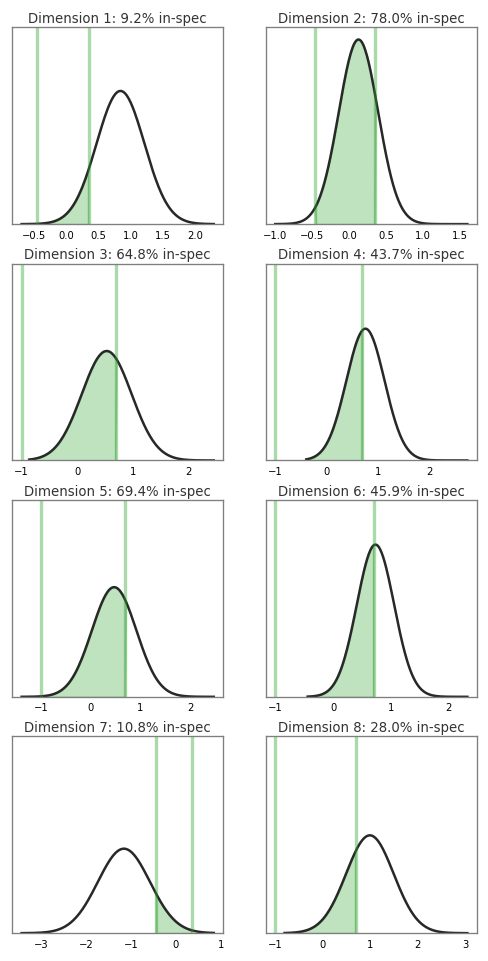

```python
plot_dist_prob(spec="in")
```

We've just calculated the probability of a part being in-spec based on a given set of upper and lower limits. Now, let's reverse the calculation - start with 99% in-spec and calculate out the upper and lower limits which would achieve this target.

Then we'll go through a list of a dozen or so percentages from 40% to 99% and calculate the total tolerance needed to widen to achieve each percentage.

```python
# Define a function to reverse calculate Lower and Upper Limits to achieve a given probability
def calc_new_limits(mean_, std_, final_prob=0.99, dims=8):
    target_dim_p = final_prob ** (1/dims)    # take the nth root as there are n dimensions
    # reverse out and find z values
    z0, z1 = stats.norm.ppf([((1-target_dim_p)/2), target_dim_p + ((1-target_dim_p)/2)])
    x0 = (z0 * std_) + mean_
    x1 = (z1 * std_) + mean_
    return x0, x1    # lower limit, upper limit

# Create a list of tuples for each dimension to plug into calc_new_limits function
def get_stats(dimension, df=df):
    _dims_ = df.loc[(df.Dim==str(dimension)) & (df.proposal=="original"), "delta"]
    mean = _dims_.mean()
    std = _dims_.std()
    return dimension, mean, std

# For dimensions 1-8, get the stats tuple
dim_mean_std = [get_stats(x) for x in range(1,9)]

# Calculate new limits based on target of 99% in spec
target_final_prob = 0.99
new_limits = [calc_new_limits(x[1], x[2], target_final_prob, dims=8) for x in dim_mean_std]

# Calculate new limits based on targets between 40-99%.
# This will give us options to chart out and choose from
new_proposals = [[calc_new_limits(x[1], x[2], target_p, dims=8) for x in dim_mean_std]
                 for target_p in np.linspace(.4, .99, 13)]
new_proposals_df_list = []
for a in new_proposals:
    new_proposals_df_list.append(pd.DataFrame(a, columns=["Proposed_LL", "Proposed_UL"],
                                              index=range(1,9)))

# Now, add in the original Upp_Tol and Low_Tol to:
    # 1) ensure we don't override a tolerance to make it tighter than the nominal value
    # 2) calculate how much each proposal widened each dimension
_toler = toler.loc[toler.proposal=="original", :]
for x in new_proposals_df_list:
    x["Orig_UL"] = _toler.set_index(np.arange(1,9)).Upp_Tol
    x["Orig_LL"] = -_toler.set_index(np.arange(1,9)).Low_Tol
    x["Final_UL_Prop"] = x.loc[:, ["Proposed_UL", "Orig_UL"]].max(axis=1)
    x["Final_LL_Prop"] = x.loc[:, ["Proposed_LL", "Orig_LL"]].min(axis=1)

# Now we have the final list of DFs with which we can get our final X values
    # (and y vals, which are the % in the linspace expression)
final_XY_vals = list(zip(np.linspace(.4, .99, 13), [x[["Final_UL_Prop", "Final_LL_Prop"]].abs() \
      .sum().sum() - x[["Orig_UL", "Orig_LL"]].abs().sum().sum() for x in new_proposals_df_list]))
```

So now we've calculated out several proposals to minimize tolerance loosened for a given in-spec percentage rate.

Let's see how the 99% proposal would look:

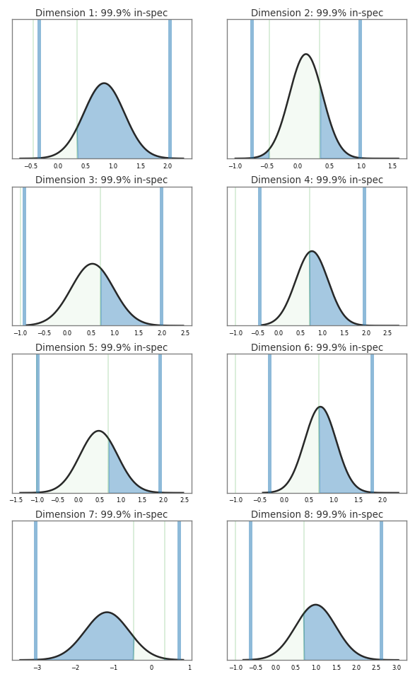

```python
def plot_dist_prob2(df=df):
    fig, axes = plt.subplots(4, 2, sharey=True, sharex=False)
    for b in range(len(axes)):
        for a in range(0,2):
            x = (b * 2) + a + 1
            x = str(x)
            ax = axes[b][a]
            sns.distplot(df.loc[(df.Dim==x) & (df.proposal=="original"), "delta"], hist=False,
                         ax=ax, fit=stats.norm, kde=False, color="b")
            kde_x, kde_y = ax.lines[0].get_data()
            x0 = -df.loc[(df.Dim==x) & (df.proposal=="original"), "Low_Tol"].mean()
            x1 = df.loc[(df.Dim==x) & (df.proposal=="original"), "Upp_Tol"].mean()
            ax.fill_between(kde_x, kde_y, where=((kde_x > x0) & (kde_x < x1)),
                            interpolate=True, color="tab:green", alpha=0.05)
            ax.axvline(x1, color="tab:green", alpha=0.2, linewidth=1)
            ax.axvline(x0, color="tab:green", alpha=0.2, linewidth=1)

            new_x0 = new_limits[int(x)-1][0]
            new_x1 = new_limits[int(x)-1][1]
            ax.axvline(new_x1, color="tab:blue", alpha=0.5, linewidth=3)
            ax.axvline(new_x0, color="tab:blue", alpha=0.5, linewidth=3)
            ax.fill_between(kde_x, kde_y, where=(((kde_x > new_x0) & (kde_x < new_x1)) &
                                                 ((kde_x < x0) | (kde_x > x1))),
                            interpolate=True, color="tab:blue", alpha=0.4)

            x_mean = df.loc[(df.Dim==x) & (df.proposal=="original"), "delta"].mean()
            x_std = df.loc[(df.Dim==x) & (df.proposal=="original"), "delta"].std()
            z0 = ((new_x0 - x_mean) / x_std)
            z1 = ((new_x1 - x_mean) / x_std)
            prob = round(calc_dual_prob(z0, z1) * 100, 1)

            ax.set_title("Dimension {}: {}% in-spec".format(x, prob), alpha=0.8, fontsize=8,
                        pad=3)
            ax.tick_params(axis="both", which="both", length=0, labelsize=5)
            ax.set_xlabel("")
            ax.set_ylim(0,2)
            for s in ["bottom", "top", "right", "left"]:
                ax.spines[s].set_color("tab:gray")
    fig.set_size_inches(6, 10)
    plt.setp(axes, yticks=[])
    plt.show()

plot_dist_prob2()
```

You'll notice each dimension was set to 99.9%, since to achieve our target of 99%, we'll need to multiply all 8 of these "99.9%" probabilities together to achieve our final throughput rate of 99%.

Now let's see what results our "statistical" proposals yield versus the original proposals:

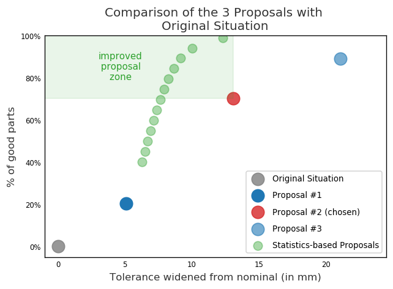

```python
plot_compare_proposals(proposals=final_XY_vals, area=True)
```

# The Results

The statistics-based proposal:

> 1. **reduces scrapped parts** to save $20,000+ (29% additional units recovered)
> 2. **ships more product**, allowing the customer to fulfill more of their demand, while at the same time
> 3. **reduces the total tolerance** the customer needs to widen

While it's a fun challenge (to some of us, that is) to go through all the statistics, standard deviations and z-values to calculate the precise upper and lower limits like we did, it's hardly necessary as a first step.

A simple and clear visualization of the problem will allow us to eyeball the optimal upper and lower limits without doing a single calculation.

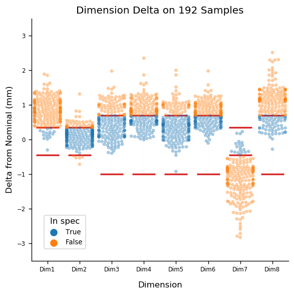

```python
def toler_catplot(proposal="original"):
    _tols = toler.loc[toler.proposal==proposal, :]
    g = sns.catplot(x="Dimension", y="delta", hue="in_spec", s=4,
                    data=df.loc[df.proposal=="original", :], alpha=0.4,
                    kind="swarm", hue_order=[True, False], legend=False)
    g.ax.legend(loc=(0.05, 0.05), title="In spec", fontsize=8)
    g.ax.set_title("Dimension Delta on 192 Samples", fontsize=12)
    plt.errorbar(_tols.index.values, [0 for x in range(8)], color="white",
                 yerr=[_tols.Low_Tol, _tols.Upp_Tol], capsize=14, elinewidth=.01,
                 markeredgewidth=2, ecolor="tab:red")
    g.ax.set_xlabel("Dimension", labelpad=10)
    plt.ylim(-3.5,3.5)
    g.ax.set_ylabel("Delta from Nominal (mm)", fontsize=10)
    g.ax.tick_params(labelsize=7)
    plt.gcf().set_size_inches((5, 5))
    plt.tight_layout()
    plt.show()

toler_catplot()
```

The above seaborn catplot graph shows which samples are out-of-spec or in-spec for each dimension, which makes it easy for us to just draw a line where an optimal cut-off point would be for each dimension.

So the lessons learned:

1. Statistics can optimize proposals and save money
2. Effective data visualization can give you great results also at a fraction of the time and effort

[figure not shown]

*Image by [Anja Heidsiek](https://pixabay.com/users/Anyusha-3791096/?utm_source=link-attribution&utm_medium=referral&utm_campaign=image&utm_content=3324368) from [Pixabay](https://pixabay.com/?utm_source=link-attribution&utm_medium=referral&utm_campaign=image&utm_content=3324368)*